# Statistical Methods for Insurance: Statistical distributions

W3.C1

## Overview of this class

- Quiz 1 solution
- Random numbers
- Mapping random numbers to events for simulation
- Statistical distributions
- Density functions
- READING: CT6, Section 1.3-1.9

## Random numbers

- True random number generators: [Radioactive decay](https://www.fourmilab.ch/hotbits/), [electromagnetic field of a vacuum](https://qrng.anu.edu.au)
- Computers only technically provide pseudo-random numbers, using deterministic process, e.g linear congruential, for large \(a, b, m\)

\[X_{n+1} = (aX_n + b) ~~mod ~~m\]

## RANDU - a bad PRNG

- Used in the 60s and onwards

\[X_{n+1} = 65539 X_n ~~mod ~~2^{31}\]

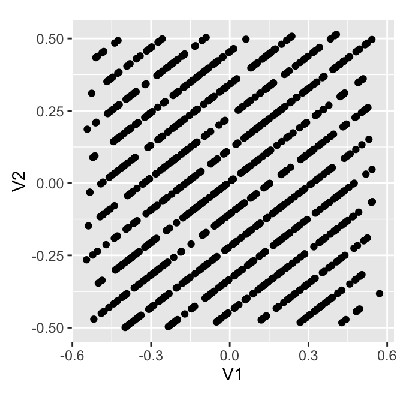

## Mersenne Twister

- algorithm is a twisted generalised feedback shift register (TGFSR)
- based on a Marsenne prime, \(2^m-1\)
- most commonly used today
- each integer will occur the same number of times in a period

## Using random numbers

- Random number tables deliver single digits 0, 1, …, 9
- When using these you need to ensure that you map these digits or combinations of the digits to match the probabilities of events
- For example, use random numbers to sample students from class
  - There are 105 students in the class
  - Need to use three sequential digits
  - BUT there are 1000 three digit numbers, so either we will throw away 895 of them, or we could map a person to multiple numbers (9) and throw away only 55
  - If any person is selected more than once, throw out repeats

## Estimate the proportion of 2420:5242

Class list:

| First | Last | numbers |
| --- | --- | --- |
| Reece | Agiazis | 001,002,003,004,005,006,007,008,009 |
| Yuan | An | 010,011,012,013,014,015,016,017,018,019 |
| Eric | Au | 020,021,022,023,024,025,026,027,028,029 |
| Travis | Barr | 030,031,032,033,034,035,036,037,038,039 |
| Prangana | Barua | 040,041,042,043,044,045,046,047,048,049 |

## Set of random digits

```
#>   [1] 3 1 4 5 1 6 3 3 0 1 0 1 1 6 0 2 0 9 9 4 7 8 1 4 5 6 4 8 1 8 5 2 7 9 7
#>  [36] 1 3 6 4 1 0 1 0 7 5 7 9 3 8 5 3 9 0 9 2 4 2 1 9 3 7 7 0 8 0 2 2 2 5 6
#>  [71] 3 8 3 5 4 2 2 6 7 6 9 6 2 3 7 4 2 1 0 2 3 5 2 4 9 7 6 6 9 8 2 4 1 8 3
#> [106] 4 4 5 2 1 2 1 9 6 9 5 7 1 7 2 4 7 3 9 1 9 9 7 5 3 6 5 8 7 5 3 5 8 6 6
#> [141] 1 0 6 6 9 5 9 0 3 2 2 0 6 5 1 6 6 6 1 4 9 1 6 4 4 5 8 2 1 2 2 3 5 8 3
#> [176] 5 8 9 0 7 2 4 7 7 0 3 4 1 0 4 6 5 2 5 9 3 1 6 6 5 3 6 9 2 2 4 4 6 5 7
#> [211] 3 9 2 4 7 8 4 6 6 0 6 2 6 4 7 8 7 8 8 4 6 8 6 6 7 1 2 3 9 0 6 3 2 3 8
#> [246] 5 9 7 4 7 7 5 8 2 9 8 5 3 0 9 6 1 2 8 8 8 3 9 3 9 5 6 7 9 8 5 2 5 5 8
#> [281] 4 8 9 2 8 5 3 6 8 1 5 8 5 2 8 6 5 4 2 1 3 6 2 5 0 6 3 0 9 4 4 0 6 4 3
```

## Just do it …

True proportion of 2420:5242 is 0.59. Sample 20 students and check this.

## Simpler approach computationally

- Use a sample function

```r
sample_class %>% sample_n(20)
```

| First | Last |
| --- | --- |
| Marcella | Davies |
| Jun | Poon |
| Chengxuan | Zeng |
| Yingxin | Huang |
| Sandra | Hendra |
| Douglas | Lloyd |
| Chin | Goh |
| Shi | Zhang |
| Jordan | Forrest |
| Menglei | Cui |
| Jiaqin | Li |
| Dewei | Qiu |
| Vincent | Jiang |
| Sylvain | Hughes |
| Prangana | Barua |
| Gurpreet | Singh |
| Xiao | Sun |
| Rebecca | Ding |
| Wanru | Liu |
| Yuying | Zhang |

## Statistical distributions

- Uniform
- Normal
- Exponential
- Binomial
- Pareto
- Weibull
- Gamma
- Lognormal

## Random numbers = Uniform

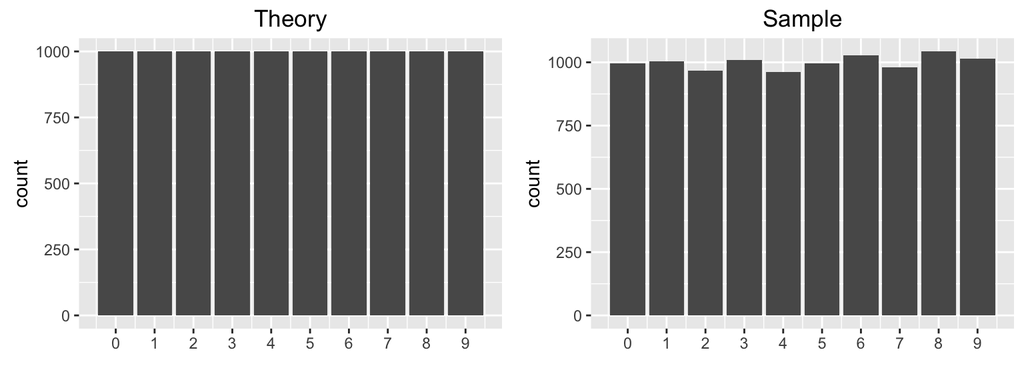

## Normal distribution

- Gaussian, bell-shaped
- symmetric, unimodal
- \(N(\mu, \sigma)\)

\[f(x~|~\mu, \sigma) = \frac{1}{\sqrt{2\pi}\sigma} e^{-\frac{(x-\mu)^2}{2\sigma^2}}, ~~~ -\infty<x<\infty\]

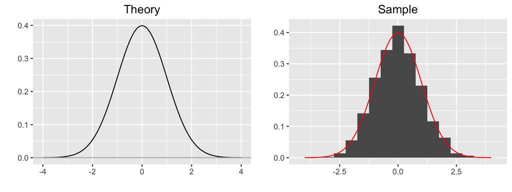

## Exponential distribution

\[f(x~|~\lambda) = e^{-\lambda x} ~~ x\geq 0\]

- right-skewed, unimodal
- \(Exp(\lambda)\)
- Arises in time between or duration of events, e.g. time between successive failures of a machine, duration of a phone call to a help center

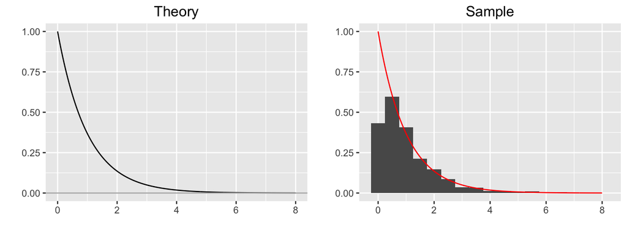

## Poisson distribution

\[P(X=x~|~\lambda) = \frac{\lambda^x e^{-\lambda}}{x!} ~~ x \in \{0, 1, 2, ...\}\]

- discrete, right-skewed, unimodal
- Arises when counting number of times event occurs in an interval of time, e.g. the number of patients arriving in an emergency room between 11 and 12 pm

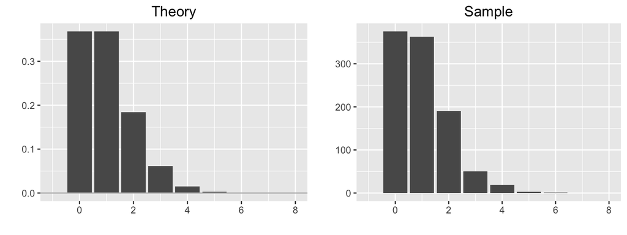

## Binomial

\[P(X=x~|~n,p) = \left(\begin{array}{c} n \\ p \end{array} \right) p^x (1-p)^{n-x} ~~ x \in \{0, 1, 2, ..., n\}\]

- discrete, unimodal, right- or left-skewed or unimodal depending on \(p\)
- Arises from counting the number of successes from \(n\) independent Bernouilli trials, e.g. the number of heads in 10 coin flips

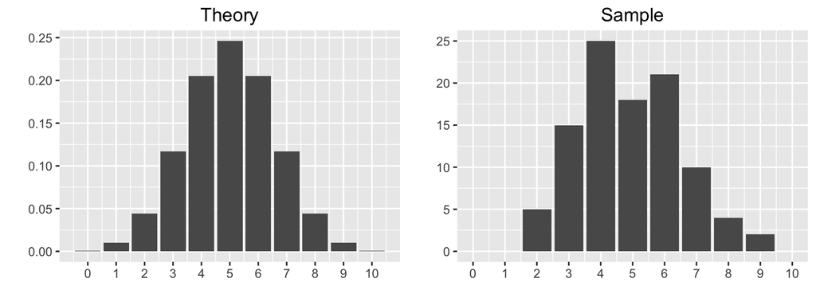

## Pareto

\[f(x~|~\alpha, \lambda) = \frac{\alpha\lambda^\alpha}{(\lambda+x)^{\alpha+1}} ~~~x>0, \alpha>0, \lambda>0 \]

- Used to describe allocation of wealth, sizes of human settlement
- Heavier tailed than exponential distribution

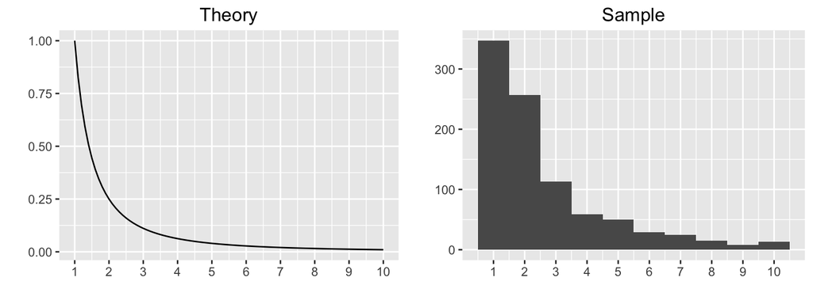

## Weibull

\[f(x~|~\lambda, k) = \frac{k}{\lambda}\left(\frac{x}{\lambda}\right)^{k-1} e^{(-x/\lambda)^k}, ~~~ x\geq 0\]

- used for particle size distribution, failure analysis, delivery time, extreme value theory
- shape changes considerably with different \(k\)

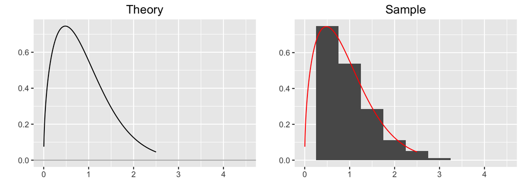

## Gamma

\[f(x~|~\alpha, \beta) = \frac{\beta^\alpha}{\Gamma(\alpha)} x^{\alpha-1}e^{-x\beta}, ~~~ x\geq 0 ~~\alpha, \beta > 0 \]

- Generalisation of exponential distribution, and also \(\chi^2\)
- \(\alpha\) changes shape substantially
- used to model size of insurance claims, rainfall

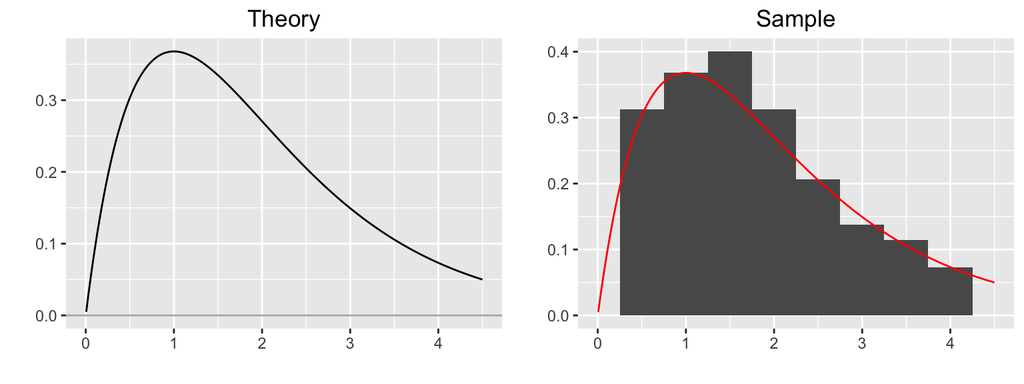

## Lognormal

- Also called Galton's distribution
- Generated when \(Y\sim N(\mu, \sigma)\), and study \(X=exp(Y)\)
- used for modeling length of comments posted in internet discussion forums, users' dwell time on the online articles, size of living tissue, highly communicable epidemics

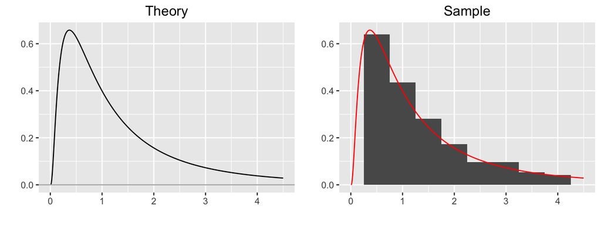

## Sampling variability

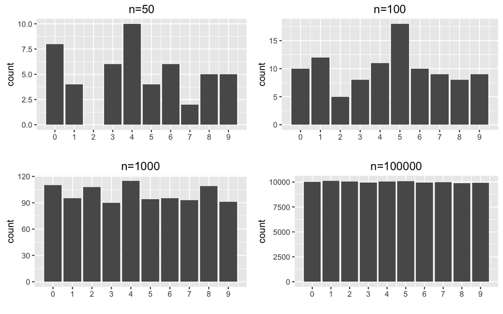

## Probability calculations

- Probability density functions are useful for computing expected quantities
- E.g. Gamma(2,1), what is the probability of seeing \(X>3.2\), or \(1.5<X<2.5\)

```r
pgamma(3.2, 2, lower.tail=FALSE)
```

```
#> [1] 0.17
```

```r
pgamma(2.5, 2) - pgamma(1.5, 2)
```

```
#> [1] 0.27
```

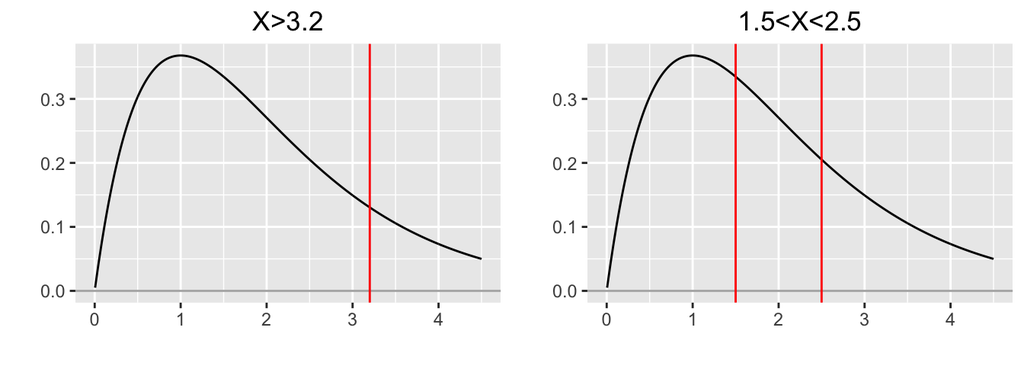

## Your turn

- Continuous distributions: Area under the curve = ______
- Discrete distributions: Sum of probabilities = ______

## Resources

- [NIST Statistics Handbook](http://www.itl.nist.gov/div898/handbook/eda/section3/eda366.htm)
- [random.org](https://www.random.org/randomness/)
- [Radioactive decay](https://www.fourmilab.ch/hotbits/)
- [electromagnetic field of a vacuum](https://qrng.anu.edu.au)
- [wikipedia](https://en.wikipedia.org/wiki/List_of_probability_distributions)

## Share and share alike

This work is licensed under the Creative Commons Attribution-Noncommercial 3.0 United States License. To view a copy of this license, visit http://creativecommons.org/licenses/by-nc/ 3.0/us/ or send a letter to Creative Commons, 171 Second Street, Suite 300, San Francisco, California, 94105, USA.